# 5일차

## 분류 모델

- 분류(Classification): 주어진 데이터를 클래스별로 구별하는 과정
- Label의 개수에 따라서 분류할 수 있음
- 이진 분류(Binary)와 다중 분류(Multiclass)로 구분
- 알고리즘: Logistic Regression, 경사 하강법(Gradient Descent), 결정 트리(Decision Tree) 등

```python
import pandas as pd

# 출처: 포르투칼 남부 algarve 지역 호텔의 자산 관리 시스템(PMS)
df = pd.read_csv('test2.csv')
df.head().T
```

|  | 0 | 1 | 2 | 3 | 4 |
| --- | --- | --- | --- | --- | --- |
| IsCanceled | 0 | 0 | 0 | 0 | 0 |
| LeadTime | 342 | 737 | 7 | 13 | 14 |
| ArrivalDateYear | 2015 | 2015 | 2015 | 2015 | 2015 |
| ArrivalDateMonth | July | July | July | July | July |
| ArrivalDateWeekNumber | 27 | 27 | 27 | 27 | 27 |
| ArrivalDateDayOfMonth | 1 | 1 | 1 | 1 | 1 |
| StaysInWeekendNights | 0 | 0 | 0 | 0 | 0 |
| StaysInWeekNights | 0 | 0 | 1 | 1 | 2 |
| Adults | 2 | 2 | 1 | 1 | 2 |
| Children | 0 | 0 | 0 | 0 | 0 |
| Babies | 0 | 0 | 0 | 0 | 0 |
| Meal | BB | BB | BB | BB | BB |
| Country | PRT | PRT | GBR | GBR | GBR |
| MarketSegment | Direct | Direct | Direct | Corporate | Online TA |
| DistributionChannel | Direct | Direct | Direct | Corporate | TA/TO |
| IsRepeatedGuest | 0 | 0 | 0 | 0 | 0 |
| PreviousCancellations | 0 | 0 | 0 | 0 | 0 |
| PreviousBookingsNotCanceled | 0 | 0 | 0 | 0 | 0 |
| ReservedRoomType | C | C | A | A | A |
| AssignedRoomType | C | C | C | A | A |
| BookingChanges | 3 | 4 | 0 | 0 | 0 |
| DepositType | No Deposit | No Deposit | No Deposit | No Deposit | No Deposit |
| Agent | NULL | NULL | NULL | 304 | 240 |
| Company | NULL | NULL | NULL | NULL | NULL |
| DaysInWaitingList | 0 | 0 | 0 | 0 | 0 |
| CustomerType | Transient | Transient | Transient | Transient | Transient |
| ADR | 0.0 | 0.0 | 75.0 | 75.0 | 98.0 |
| RequiredCarParkingSpaces | 0 | 0 | 0 | 0 | 0 |
| TotalOfSpecialRequests | 0 | 0 | 0 | 0 | 1 |
| ReservationStatus | Check-Out | Check-Out | Check-Out | Check-Out | Check-Out |
| ReservationStatusDate | 2015-07-01 | 2015-07-01 | 2015-07-02 | 2015-07-02 | 2015-07-03 |

## Business Understanding

- 어떤 분야인가? 숙박업(호텔)
- 호텔의 수익구조나 비지니스 로직은? 예약을 받아서 Checkin~CheckOut까지 서비스 제공
- 어떻게 해야 수익이 많이 날까? 가능한 모든 객실이 Full-Booking
- 수익을 극대화 하려면? 수요량을 예측하고, 예약 취소 확률을 이용해 초과예약(Over-Booking)을 관리
- 그렇다면 데이터셋에서 분석해야 할 것은? 예약 취소 확률 파악
- 예약 취소 확률 파악하려면? 예약 취소에 영향을 주는 요인을 찾아 경영에 반영할 수 있게함
- 이와 유사한 분야는? 비행기 좌석 예약, 극장 예약

## Data Understanding

#### Label

- IsCanceled: 예약 취소 여부, Label에 해당

#### Feature

- **날짜 관련**
- LeadTime: 예약 시점과 체크인 시점 간격
- ArrivalDateYear: 예약한 년도
- ArrivalDateMonth: 예약한 월
- ArrivalDateWeekNumber: 예약한 주수(1년 = 52주)
- ArrivalDateDayOfMonth: 한 달 기준 몇 번째 일로 예약했는지
- StaysInWeekendNights: 주말 숙박 일수
- StaysInWeekNights: 주중 숙박 일수
- **인원 관련**
- Adults
- Children
- Babies
- **식사, 국적 관련**
- Meal: 식사를 같이 예약했는지, 어떤 식사인지
- Country: 예약자의 국적
- **재방문 관련**
- IsRepeatedGuest: 재방문 고객 여부
- PreviousCancellations: 과거 취소이력
- **상품 관련**
- ReservedRoomType: 고객이 예약한 방의 종류
- AssignedRoomType: 고객에게 배정된 방의 종류
- BookingChanges: 예약 세부사항 변경횟수
- **예약 취소 관련**
- DepositType: 예약 취소시 환불범위
- DaysInWaitingList: wating이 발생 시 고객에 기다린 시간
- **그 외**
- ADR: 객단가, 이 값이 높을수록 영향력 있는 고객(VIP)
- RequiredCarParkingSpaces: 요구한 주차 대수
- TotalOfSpecialRequests: 예약시 특별한 요청을 한 횟수

```python
df.head().T
```

|  | 0 | 1 | 2 | 3 | 4 |
| --- | --- | --- | --- | --- | --- |
| IsCanceled | 0 | 0 | 0 | 0 | 0 |
| LeadTime | 342 | 737 | 7 | 13 | 14 |
| ArrivalDateYear | 2015 | 2015 | 2015 | 2015 | 2015 |
| ArrivalDateMonth | July | July | July | July | July |
| ArrivalDateWeekNumber | 27 | 27 | 27 | 27 | 27 |
| ArrivalDateDayOfMonth | 1 | 1 | 1 | 1 | 1 |
| StaysInWeekendNights | 0 | 0 | 0 | 0 | 0 |
| StaysInWeekNights | 0 | 0 | 1 | 1 | 2 |
| Adults | 2 | 2 | 1 | 1 | 2 |
| Children | 0 | 0 | 0 | 0 | 0 |
| Babies | 0 | 0 | 0 | 0 | 0 |
| Meal | BB | BB | BB | BB | BB |
| Country | PRT | PRT | GBR | GBR | GBR |
| MarketSegment | Direct | Direct | Direct | Corporate | Online TA |
| DistributionChannel | Direct | Direct | Direct | Corporate | TA/TO |
| IsRepeatedGuest | 0 | 0 | 0 | 0 | 0 |
| PreviousCancellations | 0 | 0 | 0 | 0 | 0 |
| PreviousBookingsNotCanceled | 0 | 0 | 0 | 0 | 0 |
| ReservedRoomType | C | C | A | A | A |
| AssignedRoomType | C | C | C | A | A |
| BookingChanges | 3 | 4 | 0 | 0 | 0 |
| DepositType | No Deposit | No Deposit | No Deposit | No Deposit | No Deposit |
| Agent | NULL | NULL | NULL | 304 | 240 |
| Company | NULL | NULL | NULL | NULL | NULL |
| DaysInWaitingList | 0 | 0 | 0 | 0 | 0 |
| CustomerType | Transient | Transient | Transient | Transient | Transient |
| ADR | 0.0 | 0.0 | 75.0 | 75.0 | 98.0 |
| RequiredCarParkingSpaces | 0 | 0 | 0 | 0 | 0 |
| TotalOfSpecialRequests | 0 | 0 | 0 | 0 | 1 |
| ReservationStatus | Check-Out | Check-Out | Check-Out | Check-Out | Check-Out |
| ReservationStatusDate | 2015-07-01 | 2015-07-01 | 2015-07-02 | 2015-07-02 | 2015-07-03 |

## 경우의 수 Column 처리

- 경우의 수를 숫자로 변환
- 컴퓨터는 학습할 때 데이터가 숫자여야 처리가 쉬움(경우의 수로 처리되는 알고리즘도 있음)
- ex) 식사 관련 Column 중 Meal의 값은 BB, HB, FB인데, 숫자로 표현하면 처리가 더 용이

#### 경우의 수 처리법

- Apply Domain Knowledge
- Frequency Encoding
- Target Encoding
- One-hot Encoding

#### Apply Domain Knowledge

- 도메인 지식을 적용하는 방법
- ex) 기준을 정했을 때 정도의 차이가 발생
- ex) 순서를 매기면 의미가 있는 경우

```python
set(df['Meal'])

# 호텔 내부에서 식사 빈도수가 증가할수록 호텔 내부 체류시간과 소비량 증가
```

```
{'BB       ', 'FB       ', 'HB       ', 'SC       ', 'Undefined'}
```

```python
# SC       : 0
# Undefined: 0
# BB       : 1
# HB       : 2
# FB       : 3

mapper = {'SC       ':0,
          'Undefined':0,
          'BB       ':1,
          'HB       ':2,
          'FB       ':3}

df['Day_stay'] = df['Meal'].map(mapper)
```

```python
df[['Meal', 'Day_stay']].head(20).T
```

|  | 0 | 1 | 2 | 3 | 4 | 5 | 6 | 7 | 8 | 9 | 10 | 11 | 12 | 13 | 14 | 15 | 16 | 17 | 18 | 19 |
| --- | --- | --- | --- | --- | --- | --- | --- | --- | --- | --- | --- | --- | --- | --- | --- | --- | --- | --- | --- | --- |
| Meal | BB | BB | BB | BB | BB | BB | BB | FB | BB | HB | BB | HB | BB | HB | BB | BB | BB | BB | BB | BB |
| Day_stay | 1 | 1 | 1 | 1 | 1 | 1 | 1 | 3 | 1 | 2 | 1 | 2 | 1 | 2 | 1 | 1 | 1 | 1 | 1 | 1 |

```python
df['Foreigner'] = 1
df.loc[df['Country'] == 'PRT', 'Foreigner'] = 0
interested = ['Foreigner', 'Country']
df[interested].head()
```

|  | Foreigner | Country |
| --- | --- | --- |
| 0 | 0 | PRT |
| 1 | 0 | PRT |
| 2 | 1 | GBR |
| 3 | 1 | GBR |
| 4 | 1 | GBR |

#### Frequency Encoding

- 경우의 수를 빈도(%)로 변환, 각 격우의 수가 데이터셋에서 차지하는 비율 적용
- 경우1의 비율: 50% -> 0.5, 경우2의 비율: 30% -> 0.3, 경우3의 비율: 20% -> 0.2로 변환

```python
df['Country'].value_counts(normalize=True)

# PRT가 0.445247: 전체 Row 중에서 Country의 PRT 데이터가 44.5% 차지
# 대략 44:56 비율로 내국인(PRT)과 외국인으로 구분됨
```

```
PRT    0.445247
GBR    0.172088
ESP    0.099934
IRL    0.054702
FRA    0.040686
         ...
BIH    0.000025
MUS    0.000025
COM    0.000025
UGA    0.000025
DJI    0.000025
Name: Country, Length: 125, dtype: float64
```

```python
cr = pd.DataFrame(df['Country'].value_counts(normalize=True)).reset_index()
cr.columns = ['Country', 'Country_Ratio']
cr.head()
```

|  | Country | Country_Ratio |
| --- | --- | --- |
| 0 | PRT | 0.445247 |
| 1 | GBR | 0.172088 |
| 2 | ESP | 0.099934 |
| 3 | IRL | 0.054702 |
| 4 | FRA | 0.040686 |

```python
df = pd.merge(df, cr)
```

```python
df.head().T
```

|  | 0 | 1 | 2 | 3 | 4 |
| --- | --- | --- | --- | --- | --- |
| IsCanceled | 0 | 0 | 0 | 0 | 1 |
| LeadTime | 342 | 737 | 0 | 9 | 85 |
| ArrivalDateYear | 2015 | 2015 | 2015 | 2015 | 2015 |
| ArrivalDateMonth | July | July | July | July | July |
| ArrivalDateWeekNumber | 27 | 27 | 27 | 27 | 27 |
| ArrivalDateDayOfMonth | 1 | 1 | 1 | 1 | 1 |
| StaysInWeekendNights | 0 | 0 | 0 | 0 | 0 |
| StaysInWeekNights | 0 | 0 | 2 | 2 | 3 |
| Adults | 2 | 2 | 2 | 2 | 2 |
| Children | 0 | 0 | 0 | 0 | 0 |
| Babies | 0 | 0 | 0 | 0 | 0 |
| Meal | BB | BB | BB | FB | BB |
| Country | PRT | PRT | PRT | PRT | PRT |
| MarketSegment | Direct | Direct | Direct | Direct | Online TA |
| DistributionChannel | Direct | Direct | Direct | Direct | TA/TO |
| IsRepeatedGuest | 0 | 0 | 0 | 0 | 0 |
| PreviousCancellations | 0 | 0 | 0 | 0 | 0 |
| PreviousBookingsNotCanceled | 0 | 0 | 0 | 0 | 0 |
| ReservedRoomType | C | C | C | C | A |
| AssignedRoomType | C | C | C | C | A |
| BookingChanges | 3 | 4 | 0 | 0 | 0 |
| DepositType | No Deposit | No Deposit | No Deposit | No Deposit | No Deposit |
| Agent | NULL | NULL | NULL | 303 | 240 |
| Company | NULL | NULL | NULL | NULL | NULL |
| DaysInWaitingList | 0 | 0 | 0 | 0 | 0 |
| CustomerType | Transient | Transient | Transient | Transient | Transient |
| ADR | 0.0 | 0.0 | 107.0 | 103.0 | 82.0 |
| RequiredCarParkingSpaces | 0 | 0 | 0 | 0 | 0 |
| TotalOfSpecialRequests | 0 | 0 | 0 | 1 | 1 |
| ReservationStatus | Check-Out | Check-Out | Check-Out | Check-Out | Canceled |
| ReservationStatusDate | 2015-07-01 | 2015-07-01 | 2015-07-03 | 2015-07-03 | 2015-05-06 |
| Day_stay | 1 | 1 | 1 | 3 | 1 |
| Foreigner | 0 | 0 | 0 | 0 | 0 |
| Country_Ratio | 0.445247 | 0.445247 | 0.445247 | 0.445247 | 0.445247 |

#### Target Encoding

- Label(Target) 정보를 경우의 수(그룹) 별로 적용
- Label이 있어야만 가능
- 과적합 될 확률이 높아짐(선입견과 고정관념이 들어감)

```python
import numpy as np

df.groupby('Country').agg(
    {'IsCanceled': np.mean}).reset_index().sort_values(by='IsCanceled')

# 빈도수가 낮은 경우의 수는 고정관념과 선입견이 발생
# 빈도수가 높은 일반화의 경우에는 필요에 따라 고정관념과 선입견이 필요함
```

|  | Country | IsCanceled |
| --- | --- | --- |
| 62 | JOR | 0.0 |
| 86 | NPL | 0.0 |
| 82 | MYS | 0.0 |
| 81 | MWI | 0.0 |
| 80 | MUS | 0.0 |
| ... | ... | ... |
| 12 | BHR | 1.0 |
| 61 | JEY | 1.0 |
| 100 | SEN | 1.0 |
| 43 | FJI | 1.0 |
| 108 | SYC | 1.0 |

125 rows × 2 columns

#### One-hot Encoding

- 경우의 수 별로 Column을 새로 만들어서 해당 경우의 수이면 1, 아니면 0
- 한 Row에서 한 Column만 Hot 함
- 일반적으로 도메인 지식을 적용할 수 없는 경우에 사용
- 경우의 수 Column 처리의 FM

```python
pd.get_dummies(df['Meal'])

# 한 Row에서 한 Column만 Hot 하다. ex) 0행은 BB이고, 3행은 FB, ...
```

|  | BB | FB | HB | SC | Undefined |
| --- | --- | --- | --- | --- | --- |
| 0 | 1 | 0 | 0 | 0 | 0 |
| 1 | 1 | 0 | 0 | 0 | 0 |
| 2 | 1 | 0 | 0 | 0 | 0 |
| 3 | 0 | 1 | 0 | 0 | 0 |
| 4 | 1 | 0 | 0 | 0 | 0 |
| ... | ... | ... | ... | ... | ... |
| 39591 | 1 | 0 | 0 | 0 | 0 |
| 39592 | 1 | 0 | 0 | 0 | 0 |
| 39593 | 1 | 0 | 0 | 0 | 0 |
| 39594 | 1 | 0 | 0 | 0 | 0 |
| 39595 | 1 | 0 | 0 | 0 | 0 |

39596 rows × 5 columns

#### 다중 공선성(Multi-colinearity)

- 일부 Column이 다른 Column과 상관 정도가 높아 부정적 영향을 미치는 현상

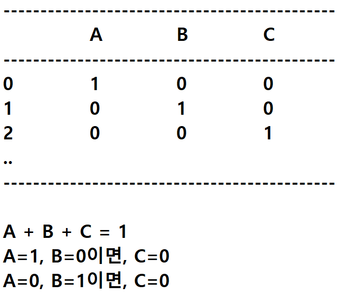

```python
pd.get_dummies(df['Country'])

# 경우의 수가 많으면 Column 수가 많아짐 ->
# 다중공선성, Feature Selection 등을 고려해 해결해야 함
```

|  | AGO | ALB | AND | ARE | ARG | ARM | AUS | AUT | AZE | BDI | ... | UGA | UKR | URY | USA | UZB | VEN | VNM | ZAF | ZMB | ZWE |
| --- | --- | --- | --- | --- | --- | --- | --- | --- | --- | --- | --- | --- | --- | --- | --- | --- | --- | --- | --- | --- | --- |
| 0 | 0 | 0 | 0 | 0 | 0 | 0 | 0 | 0 | 0 | 0 | ... | 0 | 0 | 0 | 0 | 0 | 0 | 0 | 0 | 0 | 0 |
| 1 | 0 | 0 | 0 | 0 | 0 | 0 | 0 | 0 | 0 | 0 | ... | 0 | 0 | 0 | 0 | 0 | 0 | 0 | 0 | 0 | 0 |
| 2 | 0 | 0 | 0 | 0 | 0 | 0 | 0 | 0 | 0 | 0 | ... | 0 | 0 | 0 | 0 | 0 | 0 | 0 | 0 | 0 | 0 |
| 3 | 0 | 0 | 0 | 0 | 0 | 0 | 0 | 0 | 0 | 0 | ... | 0 | 0 | 0 | 0 | 0 | 0 | 0 | 0 | 0 | 0 |
| 4 | 0 | 0 | 0 | 0 | 0 | 0 | 0 | 0 | 0 | 0 | ... | 0 | 0 | 0 | 0 | 0 | 0 | 0 | 0 | 0 | 0 |
| ... | ... | ... | ... | ... | ... | ... | ... | ... | ... | ... | ... | ... | ... | ... | ... | ... | ... | ... | ... | ... | ... |
| 39591 | 0 | 0 | 0 | 0 | 0 | 0 | 0 | 0 | 0 | 0 | ... | 0 | 0 | 0 | 0 | 0 | 0 | 0 | 0 | 0 | 0 |
| 39592 | 0 | 0 | 0 | 0 | 0 | 0 | 0 | 0 | 0 | 0 | ... | 0 | 0 | 0 | 0 | 0 | 0 | 0 | 0 | 0 | 0 |
| 39593 | 0 | 0 | 0 | 0 | 0 | 0 | 0 | 0 | 0 | 0 | ... | 0 | 0 | 0 | 0 | 0 | 0 | 0 | 0 | 0 | 0 |
| 39594 | 0 | 0 | 0 | 0 | 0 | 0 | 0 | 0 | 0 | 0 | ... | 0 | 0 | 0 | 0 | 0 | 0 | 0 | 0 | 0 | 0 |
| 39595 | 0 | 0 | 0 | 0 | 0 | 0 | 0 | 0 | 0 | 0 | ... | 0 | 0 | 0 | 0 | 0 | 0 | 0 | 0 | 0 | 0 |

39596 rows × 125 columns

```python
# one-hot encoding 할 때 경우의 수가 많은 경우 처리 방안

sum(cr[:5]['Country_Ratio'])

# 방문 빈도가 높은 5개국 출신 손님이 전체 손님 중에 80% 초과
```

```
0.8126578442266895
```

```python
sum(cr[-100:]['Country_Ratio'])

# 방문 빈도가 낮은 100개국 출신 손님이 전체 손님 중 2% 수준
```

```
0.020507121931508172
```

```python
# 방문 빈도가 높은 5개국 출신인가?

top_5 = cr[:5]['Country'].values
top_5
```

```
array(['PRT', 'GBR', 'ESP', 'IRL', 'FRA'], dtype=object)
```

```python
'GBR' in top_5
```

```
True
```

```python
def country_hot(country):
    if country in top_5:
        return country
    else:
        return 'other'
```

```python
sample = ['PRT', 'GBR', 'KOR', 'JPN']
for country in sample:
    print(country_hot(country))
```

```
PRT
GBR
other
other
```

```python
df['Country_Simple'] = df['Country'].apply(lambda x : country_hot(x))
pd.get_dummies(df['Country_Simple'])
```

|  | ESP | FRA | GBR | IRL | PRT | other |
| --- | --- | --- | --- | --- | --- | --- |
| 0 | 0 | 0 | 0 | 0 | 1 | 0 |
| 1 | 0 | 0 | 0 | 0 | 1 | 0 |
| 2 | 0 | 0 | 0 | 0 | 1 | 0 |
| 3 | 0 | 0 | 0 | 0 | 1 | 0 |
| 4 | 0 | 0 | 0 | 0 | 1 | 0 |
| ... | ... | ... | ... | ... | ... | ... |
| 39591 | 0 | 0 | 0 | 0 | 0 | 1 |
| 39592 | 0 | 0 | 0 | 0 | 0 | 1 |
| 39593 | 0 | 0 | 0 | 0 | 0 | 1 |
| 39594 | 0 | 0 | 0 | 0 | 0 | 1 |
| 39595 | 0 | 0 | 0 | 0 | 0 | 1 |

39596 rows × 6 columns

```python
if x in top_5:
    return x
else:
    return 'other'
```

```
  File "C:\Users\user\AppData\Local\Temp/ipykernel_528/3188255908.py", line 2
    return x
    ^
SyntaxError: 'return' outside function
```

```python
x if x in top_5 else 'other'
```

```python
df['Country_Simple'] = df['Country'].apply(
    lambda x : x if x in top_5 else 'other')
pd.get_dummies(df['Country_Simple'])
```

|  | ESP | FRA | GBR | IRL | PRT | other |
| --- | --- | --- | --- | --- | --- | --- |
| 0 | 0 | 0 | 0 | 0 | 1 | 0 |
| 1 | 0 | 0 | 0 | 0 | 1 | 0 |
| 2 | 0 | 0 | 0 | 0 | 1 | 0 |
| 3 | 0 | 0 | 0 | 0 | 1 | 0 |
| 4 | 0 | 0 | 0 | 0 | 1 | 0 |
| ... | ... | ... | ... | ... | ... | ... |
| 39591 | 0 | 0 | 0 | 0 | 0 | 1 |
| 39592 | 0 | 0 | 0 | 0 | 0 | 1 |
| 39593 | 0 | 0 | 0 | 0 | 0 | 1 |
| 39594 | 0 | 0 | 0 | 0 | 0 | 1 |
| 39595 | 0 | 0 | 0 | 0 | 0 | 1 |

39596 rows × 6 columns

```python
# Q1) 차를 가져오는 경우와 그렇지 않은 경우를 car_yes로 간단히 표현하세요.
# A)
df['car_yes'] = 0
df.loc[df['RequiredCarParkingSpaces'] > 0, 'car_yes'] = 1
set(df['car_yes'])
```

```
{0, 1}
```

```python
# Q2) 고객이 예약한 상품과 고객에게 할당된 상품이 같을 때와 다를 때에
#     관한 정보를 추가하세요.
#     ex) 예약한 상품과 할당된 상품이 다른 경우는 몇 %일까?

set(df['AssignedRoomType'])
```

```
{'A               ',
 'B               ',
 'C               ',
 'D               ',
 'E               ',
 'F               ',
 'G               ',
 'H               ',
 'I               ',
 'L               '}
```

```python
df['ReservedRoomType'] = df['ReservedRoomType'].apply(lambda x : x[:1])
df['AssignedRoomType'] = df['AssignedRoomType'].apply(lambda x : x[:1])
```

```python
# set(df['AssignedRoomType'])
set(df['ReservedRoomType'])
```

```
{'A', 'B', 'C', 'D', 'E', 'F', 'G', 'H', 'L'}
```

```python
df['ReservedRoomType'] + df['AssignedRoomType']
```

```
0        CC
1        CC
2        CC
3        CC
4        AA
         ..
39591    DD
39592    DD
39593    EE
39594    DD
39595    GG
Length: 39596, dtype: object
```

```python
df['RA'] = df['ReservedRoomType'] + df['AssignedRoomType']

# 같은 방을 배정 받았으면 0, 다른 방을 배정 받았으면 1
df['RA_Changed'] = df['RA'].apply(lambda x : 0 if x[0]==x[1] else 1)
np.mean(df['RA_Changed'])

# 예약한 상품과 할당된 상품이 다른 경우는 대략 20% 정도임
```

```
0.18958985756136984
```

```python
# checkpoint Code
interested = ['IsCanceled', 'LeadTime', 'ArrivalDateYear', 'ArrivalDateMonth',
       'ArrivalDateWeekNumber', 'ArrivalDateDayOfMonth',
       'StaysInWeekendNights', 'StaysInWeekNights', 'Adults', 'Children',
       'Babies', 'Meal', 'Country', 'MarketSegment', 'DistributionChannel',
       'IsRepeatedGuest', 'PreviousCancellations',
       'PreviousBookingsNotCanceled', 'ReservedRoomType', 'AssignedRoomType',
       'BookingChanges', 'DepositType', 'Agent', 'Company',
       'DaysInWaitingList', 'CustomerType', 'ADR', 'RequiredCarParkingSpaces',
       'TotalOfSpecialRequests', 'ReservationStatus', 'ReservationStatusDate',
       'Day_stay', 'Foreigner', 'Country_Ratio', 'Country_Simple', 'car_yes',
       'RA', 'RA_Changed']

df[interested].to_csv('test2_modify.csv', index=False)
```

```python
df = pd.read_csv('test2_modify.csv')
df.describe().columns
```

```
Index(['IsCanceled', 'LeadTime', 'ArrivalDateYear', 'ArrivalDateWeekNumber',
       'ArrivalDateDayOfMonth', 'StaysInWeekendNights', 'StaysInWeekNights',
       'Adults', 'Children', 'Babies', 'IsRepeatedGuest',
       'PreviousCancellations', 'PreviousBookingsNotCanceled',
       'BookingChanges', 'DaysInWaitingList', 'ADR',
       'RequiredCarParkingSpaces', 'TotalOfSpecialRequests', 'Day_stay',
       'Foreigner', 'Country_Ratio', 'car_yes', 'RA_Changed'],
      dtype='object')
```